# Using OpenDP Polars

This notebook showcases how researcher could use the Secure Data Disclosure system. It explains the different functionnalities provided by the `lomas_client` library to interact with the secure server.

The secure data are never visible by researchers. They can only access to differentially private responses via queries to the server.

Each user has access to one or multiple projects and for each dataset has a limited budget with $\epsilon$ and $\delta$ values.

```python
from rich.jupyter import print

%load_ext rich
```

from rich.jupyter import print %load_ext rich

```
The rich extension is already loaded. To reload it, use:
  %reload_ext rich
```

```python
from pathlib import Path
from IPython.display import Image

if (img := Path("images/image_demo_client.png")).exists():
    display(Image(filename=img, width=800))
```

from pathlib import Path from IPython.display import Image if (img := Path("images/image_demo_client.png")).exists(): display(Image(filename=img, width=800))

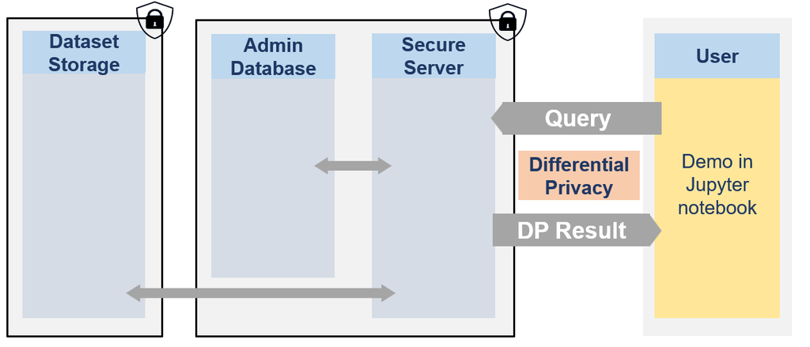

We will use the Synthetic Swiss Income Dataset to demonstrate the how to use the library `lomas_client` with polars queries.

## Step 1: Install the library

It can be installed via the pip command:

```python
import numpy as np
import opendp.prelude as dp
try:
    from lomas_client import Client
except ModuleNotFoundError:
    !pip install lomas_client
```

import numpy as np import opendp.prelude as dp try: from lomas_client import Client except ModuleNotFoundError: !pip install lomas_client

## Step 2: Initialise the client

Once the library is installed, a Client object must be created. It is responsible for sending sending requests to the server and processing responses in the local environment. It enables a seamless interaction with the server.

The client needs a few parameters to be created. Usually, these would be set in the environment by the system administrator and be transparent to lomas users. In this instance, the following code snippet sets a few of these parameters that are specific to this notebook.

```python
# The following would usually be set in the environment by a system administrator
# and be tranparent to lomas users.
# Uncomment them if you are running against a Kubernetes deployment.
# They have already been set for you if you are running locally within a devenv or the Jupyter lab set up by Docker compose.

import os
# os.environ["LOMAS_CLIENT_APP_URL"] = "https://lomas.example.com:443"
# os.environ["LOMAS_CLIENT_OIDC_DISCOVERY_URL"] = "https://dex.example.com:443/.well-known/openid-configuration"
# os.environ["LOMAS_CLIENT_TELEMETRY__ENABLED"] = "false"
# os.environ["LOMAS_CLIENT_TELEMETRY__COLLECTOR_ENDPOINT"] = "http://otel.example.com:445"
# os.environ["LOMAS_CLIENT_TELEMETRY__COLLECTOR_INSECURE"] = "true"
# os.environ["LOMAS_CLIENT_TELEMETRY__SERVICE_ID"] = "my-app-client"
# os.environ["LOMAS_CLIENT_REALM"] = "lomas"

# We set these ones because they are specific to this notebook.

os.environ["LOMAS_CLIENT_USER_NAME"] = "dr.fso@example.com"
os.environ["LOMAS_CLIENT_USER_PASSWORD"] = "dr.fso"
os.environ["LOMAS_CLIENT_DATASET_NAME"] = "FSO_INCOME_SYNTHETIC"

# Note that all client settings can also be passed as keyword arguments to the Client constructor.
# eg. client = Client(user_name = "Dr.fso") takes precedence over setting the "LOMAS_CLIENT_USER_NAME"
# environment variable.
```

# The following would usually be set in the environment by a system administrator # and be tranparent to lomas users. # Uncomment them if you are running against a Kubernetes deployment. # They have already been set for you if you are running locally within a devenv or the Jupyter lab set up by Docker compose. import os # os.environ["LOMAS_CLIENT_APP_URL"] = "https://lomas.example.com:443" # os.environ["LOMAS_CLIENT_OIDC_DISCOVERY_URL"] = "https://dex.example.com:443/.well-known/openid-configuration" # os.environ["LOMAS_CLIENT_TELEMETRY__ENABLED"] = "false" # os.environ["LOMAS_CLIENT_TELEMETRY__COLLECTOR_ENDPOINT"] = "http://otel.example.com:445" # os.environ["LOMAS_CLIENT_TELEMETRY__COLLECTOR_INSECURE"] = "true" # os.environ["LOMAS_CLIENT_TELEMETRY__SERVICE_ID"] = "my-app-client" # os.environ["LOMAS_CLIENT_REALM"] = "lomas" # We set these ones because they are specific to this notebook. os.environ["LOMAS_CLIENT_USER_NAME"] = "dr.fso@example.com" os.environ["LOMAS_CLIENT_USER_PASSWORD"] = "dr.fso" os.environ["LOMAS_CLIENT_DATASET_NAME"] = "FSO_INCOME_SYNTHETIC" # Note that all client settings can also be passed as keyword arguments to the Client constructor. # eg. client = Client(user_name = "Dr.fso") takes precedence over setting the "LOMAS_CLIENT_USER_NAME" # environment variable.

```python
client = Client()
```

client = Client()

## Step 3: Metadata and dummy dataset

### Getting dataset metadata

Dr. FSO has never seen the data and as a first step to understand what is available to her, she would like to check the metadata of the dataset. Therefore, she just needs to call the `get_dataset_metadata()` function of the client. As this is public information, this does not cost any budget.

This function returns metadata information in a format based on [SmartnoiseSQL dictionary format](https://docs.smartnoise.org/sql/metadata.html#dictionary-format), where among other, there is information about all the available columns, their type, bound values (see Smartnoise page for more details). Any metadata is required for Smartnoise-SQL is also required here and additional information such that the different categories in a string type column column can be added.

```python
income_metadata = client.get_dataset_metadata()
income_metadata
```

income_metadata = client.get_dataset_metadata() income_metadata

```
{
    '@context': ['http://www.w3.org/ns/csvw', 'csvw-eo-context.jsonld'],
    '@type': 'Table',
    'privacyUnit': None,
    'maxContributions': 1,
    'maxLength': 2032543,
    'publicLength': 2032543,
    'tableSchema': {
        'columns': [
            {
                '@type': 'Column',
                'name': 'region',
                'datatype': <DataTypes.INT: 'int'>,
                'required': None,
                'privacyId': None,
                'nullableProportion': 0.0,
                'minimum': 1,
                'maximum': 7,
                'keyValues': [1, 2, 3, 4, 5, 6, 7],
                'invariantPublicKeys': True,
                'maxNumPartitions': 7,
                'maxLength': 474690
            },
            {
                '@type': 'Column',
                'name': 'eco_branch',
                'datatype': <DataTypes.INT: 'int'>,
                'required': None,
                'privacyId': None,
                'nullableProportion': 0.0,
                'minimum': 8,
                'maximum': 96,
                'keyValues': [
                    8,
                    10,
                    11,
                    13,
                    14,
                    15,
                    16,
```

[output cut: 159 more lines]

```
                'minimum': 1000,
                'maximum': 100000
            }
        ]
    },
    'additionalInformation': [
        {'@type': 'ColumnGroup', 'columnsInGroup': ['region', 'sex'], 'invariantPublicKeys': True},
        {'@type': 'ColumnGroup', 'columnsInGroup': ['education', 'sex'], 'invariantPublicKeys': True},
        {
            '@type': 'ColumnGroup',
            'columnsInGroup': ['profession', 'sex'],
            'invariantPublicKeys': True
        }
    ]
}
```

### Get a dummy dataset

Now, that she has seen and understood the metadata, she wants to get an even better understanding of the dataset (but is still not able to see it). A solution to have an idea of what the dataset looks like it to create a dummy dataset.

Based on the public metadata of the dataset, a random dataframe can be created created. By default, there will be 100 rows and the seed is set to 42 to ensure reproducibility, but these 2 variables can be changed to obtain different dummy datasets. Getting a dummy dataset does not affect the budget as there is no differential privacy here. It is not a synthetic dataset and all that could be learn here is already present in the public metadata (it is created randomly on the fly based on the metadata).

Dr. FSO first create a dummy dataset with 200 rows and chooses a seed of 0.

```python
NB_ROWS = 200
SEED = 0
```

NB_ROWS = 200 SEED = 0

```python
dummy_lf = client.get_dummy_dataset(nb_rows=NB_ROWS, seed=SEED, lazy=True)
print(dummy_lf.collect())
```

dummy_lf = client.get_dummy_dataset(nb_rows=NB_ROWS, seed=SEED, lazy=True) print(dummy_lf.collect())

```
shape: (200, 7)
┌────────┬────────────┬────────────┬───────────┬─────┬─────┬──────────────┐
│ region ┆ eco_branch ┆ profession ┆ education ┆ age ┆ sex ┆ income       │
│ ---    ┆ ---        ┆ ---        ┆ ---       ┆ --- ┆ --- ┆ ---          │
│ i64    ┆ i64        ┆ i64        ┆ i64       ┆ i64 ┆ i64 ┆ f64          │
╞════════╪════════════╪════════════╪═══════════╪═════╪═════╪══════════════╡
│ 3      ┆ 80         ┆ 51         ┆ 5         ┆ 67  ┆ 1   ┆ 19871.13848  │
│ 6      ┆ 81         ┆ 37         ┆ 2         ┆ 34  ┆ 1   ┆ 22489.650926 │
│ 2      ┆ 66         ┆ 29         ┆ 7         ┆ 7   ┆ 1   ┆ 83238.732286 │
│ 5      ┆ 84         ┆ 94         ┆ 5         ┆ 45  ┆ 1   ┆ 43159.767789 │
│ 7      ┆ 57         ┆ 17         ┆ 5         ┆ 13  ┆ 0   ┆ 40435.219559 │
│ …      ┆ …          ┆ …          ┆ …         ┆ …   ┆ …   ┆ …            │
│ 2      ┆ 57         ┆ 32         ┆ 7         ┆ 87  ┆ 1   ┆ 19919.917073 │
│ 2      ┆ 47         ┆ 48         ┆ 8         ┆ 43  ┆ 1   ┆ 55029.139023 │
│ 3      ┆ 84         ┆ 67         ┆ 6         ┆ 27  ┆ 1   ┆ 88960.498804 │
│ 5      ┆ 58         ┆ 11         ┆ 1         ┆ 78  ┆ 0   ┆ 57863.426762 │
│ 1      ┆ 68         ┆ 65         ┆ 8         ┆ 90  ┆ 0   ┆ 55553.454584 │
└────────┴────────────┴────────────┴───────────┴─────┴─────┴──────────────┘
```

```python
test = client.get_dummy_dataset(nb_rows=NB_ROWS, seed = SEED)
test.dtypes
```

test = client.get_dummy_dataset(nb_rows=NB_ROWS, seed = SEED) test.dtypes

```
region          Int64
eco_branch      Int64
profession      Int64
education       Int64
age             Int64
sex             Int64
income        float64
dtype: object
```

## Step 4: Prepare the pipeline

It is necessary to prepare the pipeline before sending the query to the client.

```python
import polars as pl
pl.__name__, pl.__version__
```

import polars as pl pl.__name__, pl.__version__

```
('polars', '1.36.1')
```

### a. mean

```python
# Income bounds
income_meta = client.get_column_metadata("income")
income_lower_bound, income_upper_bound = income_meta["minimum"], income_meta["maximum"]
```

# Income bounds income_meta = client.get_column_metadata("income") income_lower_bound, income_upper_bound = income_meta["minimum"], income_meta["maximum"]

```python
# Get a context
context = client.get_context(epsilon=1.0)
```

# Get a context context = client.get_context(epsilon=1.0)

```python
plan = (context.query().select(
    pl.col("income").dp.mean(bounds=(income_lower_bound, income_upper_bound)), dp.len()
))
print(plan.explain(optimized=True))
```

plan = (context.query().select( pl.col("income").dp.mean(bounds=(income_lower_bound, income_upper_bound)), dp.len() )) print(plan.explain(optimized=True))

```
SELECT [col("income").lib/python3.14/site-packages/opendp/lib/opendp.abi3.so:dp_mean(),
null.lib/python3.14/site-packages/opendp/lib/opendp.abi3.so:dp_frame_len()]
  DF ["region", "eco_branch", "profession", "education", ...]; PROJECT["income"] 1/7 COLUMNS
```

**You can first visualize with polars**

```python
# same query written only with polars on the local dummy lazyframe
plan_polars = (dummy_lf.select(
    pl.col("income").mean(), pl.len()
)).collect()
plan_polars
```

# same query written only with polars on the local dummy lazyframe plan_polars = (dummy_lf.select( pl.col("income").mean(), pl.len() )).collect() plan_polars

shape: (1, 2)

| income f64 | len u32 |
| --- | --- |
| 52132.572384 | 200 |

**You can also directly try your plan with your local context**

```python
result_dummy_dp = plan.release().collect()
result_dummy_dp
```

result_dummy_dp = plan.release().collect() result_dummy_dp

shape: (1, 2)

| income f64 | len u32 |
| --- | --- |
| 51741.095862 | 100 |

## Step 5: Send the queries

### a. Dummy queries

```python
res = client.opendp.query(plan, dummy = True, nb_rows = NB_ROWS, seed=SEED, epsilon=1.0)

print(res.result.value)
```

res = client.opendp.query(plan, dummy = True, nb_rows = NB_ROWS, seed=SEED, epsilon=1.0) print(res.result.value)

```
shape: (1, 2)
┌──────────────┬─────┐
│ income       ┆ len │
│ ---          ┆ --- │
│ f64          ┆ i64 │
╞══════════════╪═════╡
│ 52131.955658 ┆ 200 │
└──────────────┴─────┘
```

By default, the client will use a laplace mechanism. Note that Dr. FSO can also use a Gaussian mechanism if wanted.

```python
# Specifying rho would tell opendp to use the Gaussian mechanism
res = client.opendp.query(plan, rho=0.5, delta = 1e-6, dummy = True, nb_rows = NB_ROWS, seed=SEED)

print(res.result.value)
```

# Specifying rho would tell opendp to use the Gaussian mechanism res = client.opendp.query(plan, rho=0.5, delta = 1e-6, dummy = True, nb_rows = NB_ROWS, seed=SEED) print(res.result.value)

```
shape: (1, 2)
┌──────────────┬─────┐
│ income       ┆ len │
│ ---          ┆ --- │
│ f64          ┆ i64 │
╞══════════════╪═════╡
│ 52131.981078 ┆ 200 │
└──────────────┴─────┘
```

### b. budget estimation

```python
res = client.opendp.cost(plan, epsilon=1.0)

res
```

res = client.opendp.cost(plan, epsilon=1.0) res

```
CostResponse(epsilon=1.0, delta=0.0, response_type=<QueryResponseTypes.COST: 'cost'>)
```

```python
res = client.opendp.cost(plan, rho = 0.5, delta=1e-6, approx_zcdp=True)

res
```

res = client.opendp.cost(plan, rho = 0.5, delta=1e-6, approx_zcdp=True) res

```
CostResponse(epsilon=5.22153444453017, delta=1e-06, response_type=<QueryResponseTypes.COST: 'cost'>)
```

### c. Actual queries

```python
res = client.opendp.query(plan, epsilon=1.0)

print(res.result.value)
```

res = client.opendp.query(plan, epsilon=1.0) print(res.result.value)

```
shape: (1, 2)
┌─────────────┬─────────┐
│ income      ┆ len     │
│ ---         ┆ ---     │
│ f64         ┆ i64     │
╞═════════════╪═════════╡
│ 7052.657768 ┆ 2032543 │
└─────────────┴─────────┘
```

```python
res = client.opendp.query(plan, rho = 0.5, delta = 0.001)

print(res.result.value)
```

res = client.opendp.query(plan, rho = 0.5, delta = 0.001) print(res.result.value)

```
shape: (1, 2)
┌─────────────┬─────────┐
│ income      ┆ len     │
│ ---         ┆ ---     │
│ f64         ┆ i64     │
╞═════════════╪═════════╡
│ 7052.657851 ┆ 2032543 │
└─────────────┴─────────┘
```

## Group_by examples

```python
context = client.get_context(epsilon=1.0)
# Grouped by "sex"
plan = context.query().group_by("sex").agg([
    pl.col("income").dp.mean(bounds=(income_lower_bound, income_upper_bound))
])
```

context = client.get_context(epsilon=1.0) # Grouped by "sex" plan = context.query().group_by("sex").agg([ pl.col("income").dp.mean(bounds=(income_lower_bound, income_upper_bound)) ])

```python
res = client.opendp.query(plan, dummy=True, epsilon=1.0)
print(res.result.value)
```

res = client.opendp.query(plan, dummy=True, epsilon=1.0) print(res.result.value)

```
shape: (2, 2)
┌─────┬──────────────┐
│ sex ┆ income       │
│ --- ┆ ---          │
│ i64 ┆ f64          │
╞═════╪══════════════╡
│ 1   ┆ 51586.397084 │
│ 0   ┆ 53048.954894 │
└─────┴──────────────┘
```

```python
plan = context.query().group_by(["sex","region"]).agg([
    pl.col("income").dp.mean(bounds=(income_lower_bound, income_upper_bound))
])
```

plan = context.query().group_by(["sex","region"]).agg([ pl.col("income").dp.mean(bounds=(income_lower_bound, income_upper_bound)) ])

```python
res = client.opendp.query(plan, dummy=True, epsilon=1.0, delta=0.001)

print(res.result.value)
```

res = client.opendp.query(plan, dummy=True, epsilon=1.0, delta=0.001) print(res.result.value)

```
shape: (14, 3)
┌─────┬────────┬───────────────┐
│ sex ┆ region ┆ income        │
│ --- ┆ ---    ┆ ---           │
│ i64 ┆ i64    ┆ f64           │
╞═════╪════════╪═══════════════╡
│ 1   ┆ 5      ┆ 33890.504544  │
│ 0   ┆ 7      ┆ 79369.832694  │
│ 0   ┆ 3      ┆ 110996.960978 │
│ 0   ┆ 2      ┆ 59953.781419  │
│ 1   ┆ 1      ┆ 14922.443597  │
│ …   ┆ …      ┆ …             │
│ 1   ┆ 3      ┆ -68849.733152 │
│ 0   ┆ 6      ┆ 1076.512929   │
│ 1   ┆ 7      ┆ 32417.371184  │
│ 0   ┆ 1      ┆ 60332.947983  │
│ 0   ┆ 5      ┆ 72590.725128  │
└─────┴────────┴───────────────┘
```

```python
res = client.opendp.cost(plan, rho=0.5, delta = 1e-6)

print(res)
```

res = client.opendp.cost(plan, rho=0.5, delta = 1e-6) print(res)

```
CostResponse(epsilon=5.22153444453017, delta=1e-06)
```

## Quantile examples

```python
candidates = list(range(1_000, 100_000, 1000))
```

candidates = list(range(1_000, 100_000, 1000))

```python
plan = context.query().select(
    pl.col("income").dp.quantile(alpha=.75, candidates=candidates)
)
```

plan = context.query().select( pl.col("income").dp.quantile(alpha=.75, candidates=candidates) )

```python
res = client.opendp.query(plan, epsilon=1.0)

print(res.result.value)
```

res = client.opendp.query(plan, epsilon=1.0) print(res.result.value)

```
shape: (1, 1)
┌────────┐
│ income │
│ ---    │
│ i64    │
╞════════╡
│ 8000   │
└────────┘
```

### Quantile with group_by

```python
plan = context.query().group_by("sex").agg([
    pl.col("income").dp.quantile(alpha=.25, candidates=candidates),
])
```

plan = context.query().group_by("sex").agg([ pl.col("income").dp.quantile(alpha=.25, candidates=candidates), ])

```python
res = client.opendp.query(plan, epsilon=1.0)

print(res.result.value)
```

res = client.opendp.query(plan, epsilon=1.0) print(res.result.value)

```
shape: (2, 2)
┌─────┬────────┐
│ sex ┆ income │
│ --- ┆ ---    │
│ i64 ┆ i64    │
╞═════╪════════╡
│ 1   ┆ 6000   │
│ 0   ┆ 5000   │
└─────┴────────┘
```

### Quantile with group_by on mulitple columns

```python
plan = context.query().group_by(["sex", "region"]).agg([
    pl.col("income").dp.quantile(alpha=.75, candidates=candidates),
])
```

plan = context.query().group_by(["sex", "region"]).agg([ pl.col("income").dp.quantile(alpha=.75, candidates=candidates), ])

```python
res = client.opendp.query(plan, epsilon=1.0)

print(res.result.value)
```

res = client.opendp.query(plan, epsilon=1.0) print(res.result.value)

```
shape: (14, 3)
┌─────┬────────┬────────┐
│ sex ┆ region ┆ income │
│ --- ┆ ---    ┆ ---    │
│ i64 ┆ i64    ┆ i64    │
╞═════╪════════╪════════╡
│ 0   ┆ 7      ┆ 6000   │
│ 0   ┆ 1      ┆ 8000   │
│ 0   ┆ 6      ┆ 8000   │
│ 1   ┆ 2      ┆ 9000   │
│ 1   ┆ 1      ┆ 9000   │
│ …   ┆ …      ┆ …      │
│ 0   ┆ 5      ┆ 7000   │
│ 0   ┆ 3      ┆ 8000   │
│ 1   ┆ 4      ┆ 9000   │
│ 1   ┆ 6      ┆ 9000   │
│ 1   ┆ 5      ┆ 8000   │
└─────┴────────┴────────┘
```

### Income distribution for partitions of the population:

#### Prepare the pipeline

```python
import seaborn as sns
import matplotlib.pyplot as plt
import pandas as pd
```

import seaborn as sns import matplotlib.pyplot as plt import pandas as pd

```python
# Partitions
PARTITIONS = ['sex', 'region']
# Prepare a list of candidates
candidates = [x * 250.0 for x in range(8, 52)]
```

# Partitions PARTITIONS = ['sex', 'region'] # Prepare a list of candidates candidates = [x * 250.0 for x in range(8, 52)]

```python
def make_quantile_pipeline(quantile):
    # Create expression
    return context.query().group_by(["sex", "region"]).agg([
        pl.col("income").dp.quantile(alpha=quantile, candidates=candidates),
    ])
```

def make_quantile_pipeline(quantile): # Create expression return context.query().group_by(["sex", "region"]).agg([ pl.col("income").dp.quantile(alpha=quantile, candidates=candidates), ])

```python
q25 = make_quantile_pipeline(0.25)
q50 = make_quantile_pipeline(0.5)
q75 = make_quantile_pipeline(0.75)
```

q25 = make_quantile_pipeline(0.25) q50 = make_quantile_pipeline(0.5) q75 = make_quantile_pipeline(0.75)

```python
r25 = client.opendp.query(q25, epsilon=1)
r50 = client.opendp.query(q50, epsilon=1)
r75 = client.opendp.query(q75, epsilon=1)
```

r25 = client.opendp.query(q25, epsilon=1) r50 = client.opendp.query(q50, epsilon=1) r75 = client.opendp.query(q75, epsilon=1)

Let us put together the results and show them in a table. Notice that the output is a polars dataframe, we thus need to transform it to a pandas DataFrame if we want to work with pandas.

```python
r25 = r25.result.value.to_pandas()
r50 = r50.result.value.to_pandas()
r75 = r75.result.value.to_pandas()
```

r25 = r25.result.value.to_pandas() r50 = r50.result.value.to_pandas() r75 = r75.result.value.to_pandas()

```python
results = pd.merge(r25, r50, on=PARTITIONS, suffixes=('_25', '_50'))
results = pd.merge(results, r75, on=PARTITIONS)
results.sort_values(by = ['region', 'sex']).head()
```

results = pd.merge(r25, r50, on=PARTITIONS, suffixes=('_25', '_50')) results = pd.merge(results, r75, on=PARTITIONS) results.sort_values(by = ['region', 'sex']).head()

|  | sex | region | income_25 | income_50 | income |
| --- | --- | --- | --- | --- | --- |
| 13 | 0 | 1 | 5000.0 | 6250.0 | 7750.0 |
| 0 | 1 | 1 | 5750.0 | 7000.0 | 8750.0 |
| 8 | 0 | 2 | 4750.0 | 6000.0 | 7250.0 |
| 9 | 1 | 2 | 5500.0 | 7000.0 | 8500.0 |
| 1 | 0 | 3 | 5000.0 | 6250.0 | 7750.0 |

#### Visualise results

```python
def quantile_data(q1, q2, q3):
    return np.concatenate((np.random.uniform(q1, q2, size=50), np.random.uniform(q2, q3, size=50)))

results['data'] = results.apply(
    lambda row: quantile_data(row["income_25"], row["income_50"], row["income"]),
    axis=1,
)
results['sex'] = results['sex'].replace({0: 'woman', 1: 'man'})
results['region'] = results['region'].replace({1: 'Lemanique', 2: 'Mittleland', 3: 'North-West', 4: 'Zürich', 5: 'Oriental', 6: 'Central', 7: 'Ticino'})
results = results.explode('data', ignore_index=True)
```

def quantile_data(q1, q2, q3): return np.concatenate((np.random.uniform(q1, q2, size=50), np.random.uniform(q2, q3, size=50))) results['data'] = results.apply( lambda row: quantile_data(row["income_25"], row["income_50"], row["income"]), axis=1, ) results['sex'] = results['sex'].replace({0: 'woman', 1: 'man'}) results['region'] = results['region'].replace({1: 'Lemanique', 2: 'Mittleland', 3: 'North-West', 4: 'Zürich', 5: 'Oriental', 6: 'Central', 7: 'Ticino'}) results = results.explode('data', ignore_index=True)

```python
plt.figure(figsize=(10, 6))
sns.boxplot(x="region", y="data", hue="sex", data=results, palette="Set1", width=0.5);
plt.xticks(fontsize=12)
plt.yticks(fontsize=12)
plt.xlabel('Regions', fontsize=15)
plt.ylabel('Income per month (in CHF)', fontsize=15)
plt.title('Income per partition of the population', fontsize=16)
plt.show()
```

plt.figure(figsize=(10, 6)) sns.boxplot(x="region", y="data", hue="sex", data=results, palette="Set1", width=0.5); plt.xticks(fontsize=12) plt.yticks(fontsize=12) plt.xlabel('Regions', fontsize=15) plt.ylabel('Income per month (in CHF)', fontsize=15) plt.title('Income per partition of the population', fontsize=16) plt.show()

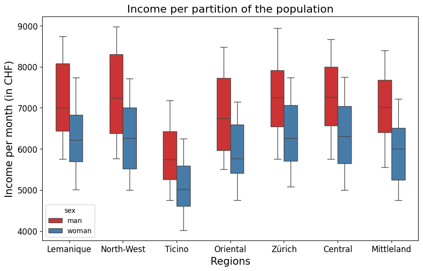